# kmeans

Jacob Buffa

March 21, 2020

## MODEL OBJECTIVE

I believe there are 3 types of athletes based on movement abilities and physiology. I want to to if an unsupervised learning model identifies the same clusters.

A kmeans model was chosen as the prefered unsupervised clustering method

### Load Libraries & Data

```r
library(tidyverse)
library(factoextra)
```

```r
# Scoring Function
custom.scoring <- function(x){
  scale(x)*10+50
}

# Tables
athleteInfo <- read.csv("AthleteInformation1.csv")
allData <- read.csv("FINAL TABLE.csv")
```

### Data Processing

```r
# ORGANIZE
athleteInfo <-
  athleteInfo %>%
  transform(Birthday = as.Date(Birthday, format = "%m/%d/%Y")) %>%
  mutate(Gender = ifelse(Gender == "F", "F","M"))

masterData <-
  allData %>%
  mutate(Avg..Relative.Braking.Force = (Avg..Braking.Force/System.Weight)*100,
         Avg..Relative.Braking.Power = Avg..Braking.Power/System.Weight,
         Avg..Relative.Propulsive.Power = Avg..Propulsive.Power/System.Weight) %>%
  transform(Date = as.Date(Date, format = "%m/%d/%Y"),
            Name = as.character(Name)) %>%
  left_join(athleteInfo, by = "Name") %>%
  filter(Gender == "M")

variables <- colnames(masterData)
brakingMetrics <- variables[c(5:7,12,13,16,17,19)]
propulsiveMetrics <- variables[c(9:11,14,15,47,53:55)]
balanceMetrics <- variables[c(25:34)]

# CENTER AND SCALE
clusterData <- masterData %>%
  mutate_at(vars(brakingMetrics,propulsiveMetrics), custom.scoring) %>%
  group_by(Name) %>%
  summarise_at(vars(brakingMetrics, propulsiveMetrics), mean, na.rm = TRUE)
clusterData <- na.omit(clusterData) # remove NA

kmeansData <-
  clusterData %>%
  group_by(Name) %>%
  transmute(Velo.Diff = Avg..Propulsive.Velocity - Takeoff.Velocity,
            Force.Velo.Diff = Avg..Propulsive.Force - Avg..Propulsive.Velocity,
            Braking.Diff = Avg..Braking.Force - Avg..Braking.Velocity)

# IDENTIFY CORRELATED PREDICTORS
cormatrix <- cor(clusterData[,-1])
summary(cormatrix[upper.tri(cormatrix)])
```

```
##    Min. 1st Qu.  Median    Mean 3rd Qu.    Max.
## -0.9685 -0.4172  0.2294  0.1205  0.6159  0.9519
```

```r
#highlyCor <- findCorrelation(cormatrix, cutoff = .8)
#filterclusterData <- clusterData[,-highlyCor]
```

Data has been cleaned, centered, and scaled for the model. Normally would elimate linear dependencies, but Performance Driver metrics have been selected based on domain expertise. There is an alternative Dataset based solely on metric differences that match the logic created on the Force Plate Breakdown file.

### Model Training & Tuning

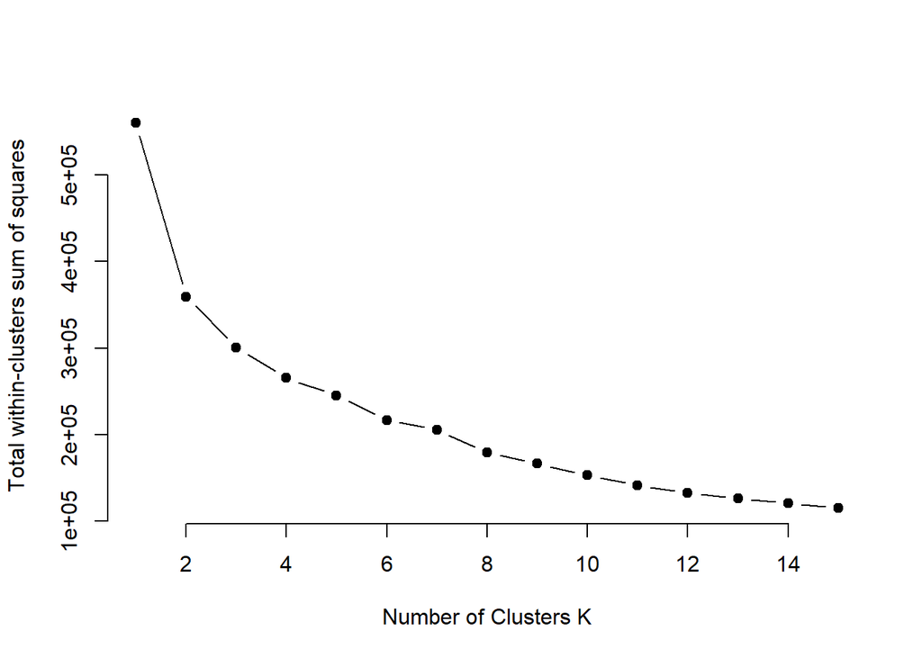

```r
# check optimal number for K
k.max <- 15

wss <- sapply(1:k.max, function(k) {
  kmeans(clusterData[,-1], k, nstart = 50, iter.max = 15)$tot.withinss
})

plot(1:k.max, wss,
     type = "b",
     pch = 19,
     frame = FALSE,
     xlab = "Number of Clusters K",
     ylab = "Total within-clusters sum of squares")
```

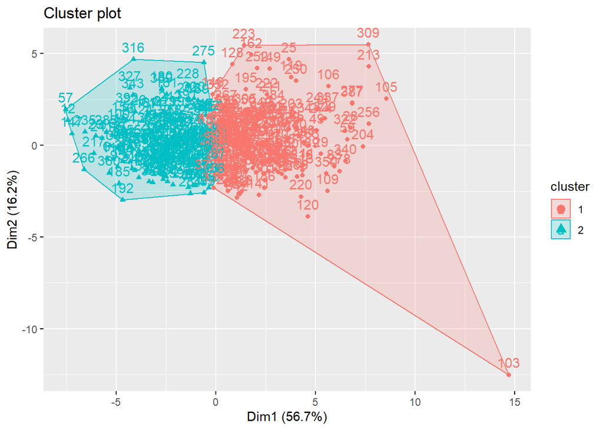

```r
# labels for k = 2
k2 <- kmeans(clusterData[,-1], 2)
fviz_cluster(k2, data = clusterData[,-1])
```

```r
k2$centers
```

```
##   Avg..Braking.Force Avg..Braking.Power Avg..Braking.Velocity
## 1           54.10742           46.76076              47.84818
## 2           41.98662           58.58485              57.46617
##   Avg..Relative.Braking.Force Avg..Relative.Braking.Power Braking.Net.Impulse
## 1                    53.68214                    47.39616            53.05506
## 2                    42.64227                    57.93017            41.56708
##   Braking.Phase Braking.RFD Avg..Propulsive.Force Avg..Propulsive.Power
## 1      46.09208    55.05750              55.11193              55.89317
## 2      54.11502    42.45993              42.19187              40.95671
##   Avg..Propulsive.Velocity Avg..Relative.Propulsive.Force
## 1                 54.81120                       54.59730
## 2                 42.82569                       44.87963
##   Avg..Relative.Propulsive.Power Propulsive.Net.Impulse      RSI Stiffness
## 1                       54.92818               54.97162 50.18036  49.74049
## 2                       43.45538               41.39106 48.58600  50.06128
##   Takeoff.Velocity
## 1         54.35818
## 2         43.10210
```

Next is to try using the dataset with only metric differences.

### Second Model Training & Tuning

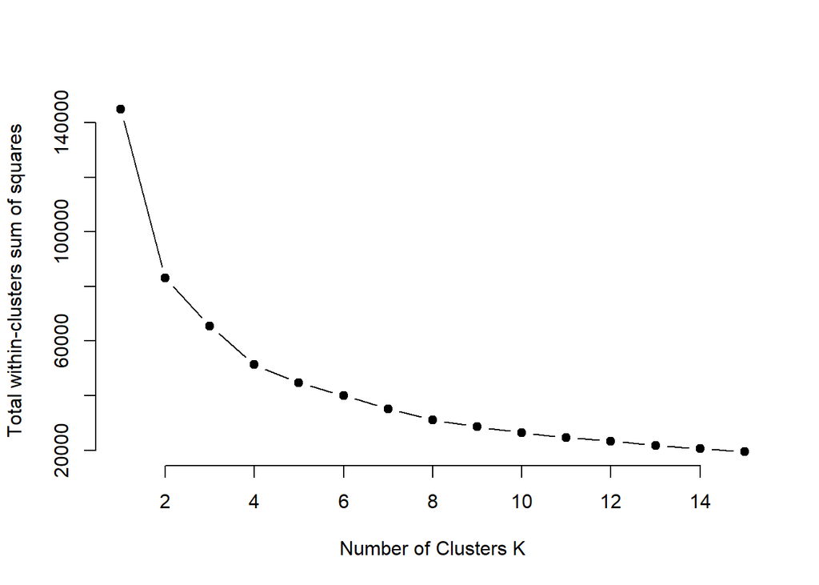

```r
# check optimal number for K
k.max <- 15

wss <- sapply(1:k.max, function(k) {
  kmeans(kmeansData[,-1], k, nstart = 50, iter.max = 15)$tot.withinss
})

plot(1:k.max, wss,
     type = "b",
     pch = 19,
     frame = FALSE,
     xlab = "Number of Clusters K",
     ylab = "Total within-clusters sum of squares")
```

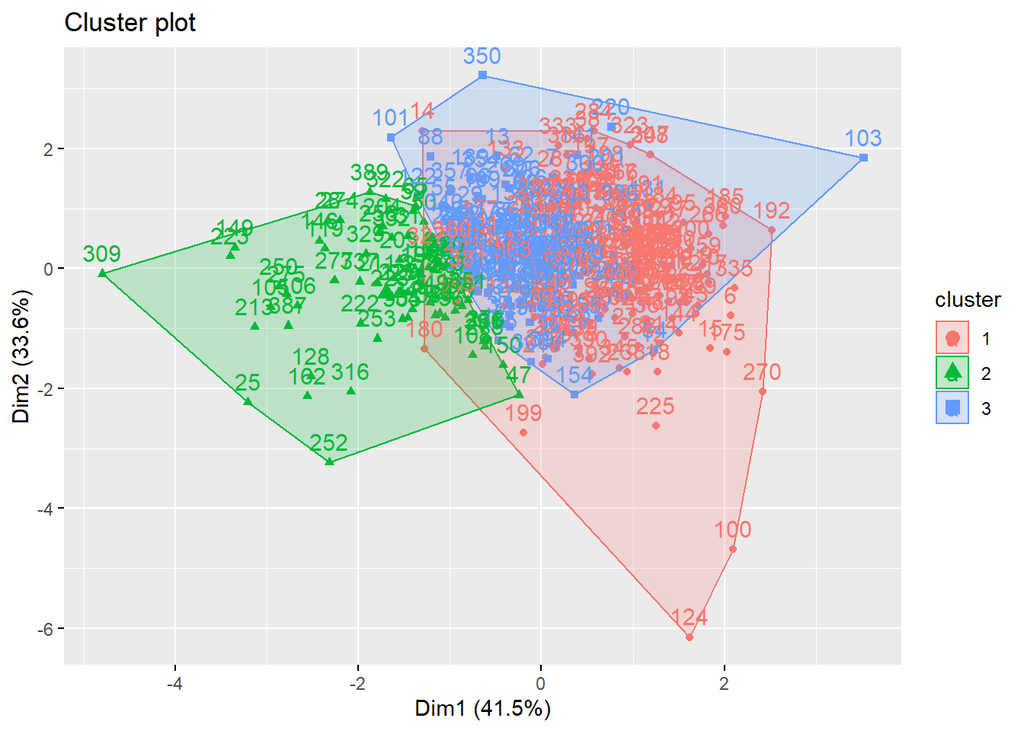

```r
# labels for k = 3
k3 <- kmeans(kmeansData[,-1], 3)
fviz_cluster(k3, data = kmeansData[,-1])
```

```r
k3$centers
```

```
##    Velo.Diff Force.Velo.Diff Braking.Diff
## 1 -0.3602747       -1.382279   -17.460540
## 2  1.2658712       12.197716    15.508935
## 3  0.1439898       -4.282166     3.279244
```

This model supported the logic created fairly well. However, there was significant overlap between groups and total within cluster sum of squares was not very good.

### Conclusion

Based on scores alone, unsupervised learning model will cluster athletes based on overall ability (Bad, Average, Good, etc.). Based on metric differences, the model clusters athletes based on the same logic, but is highly inaccurate. A tree based model with more than just metric differences may be best. But this is useful to know the model is seeing what we see.